# Lab 4

October 24 2017

## Working with R

## R

- free and open-source
- highly popular both in academia and business
- powerful, flexible, and capable
- works on almost every OS, both on desktop computers and in cloud
- integrates well with other software (e.g. SPSS)
- **powerful packages for Bayesian analysis (MCMCpack, rjags, rstan)**

## R plotting capabilities

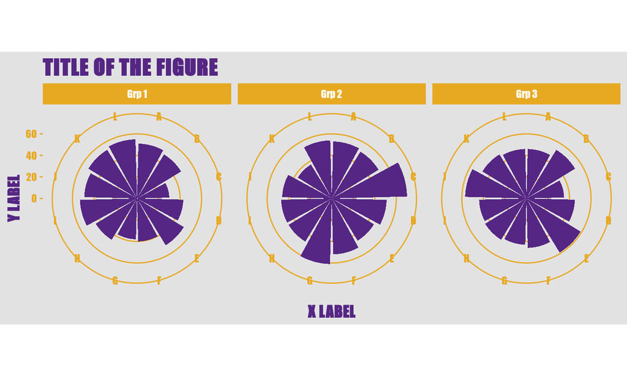

## R plotting capabilities

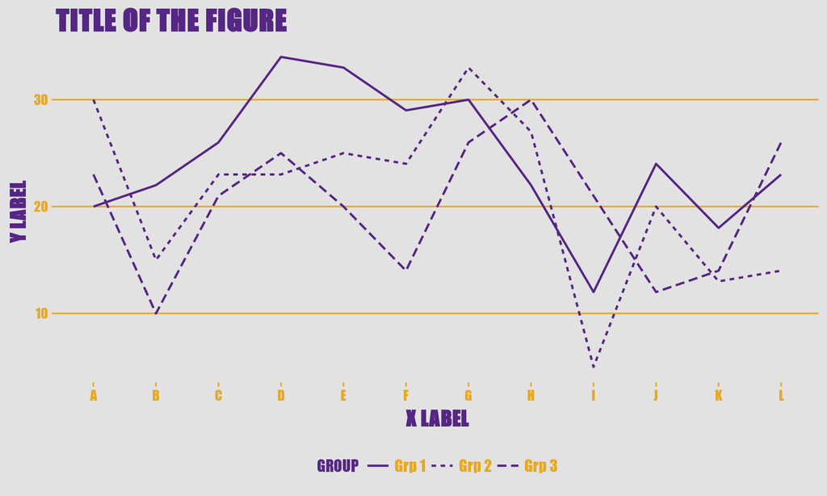

## R plotting capabilities

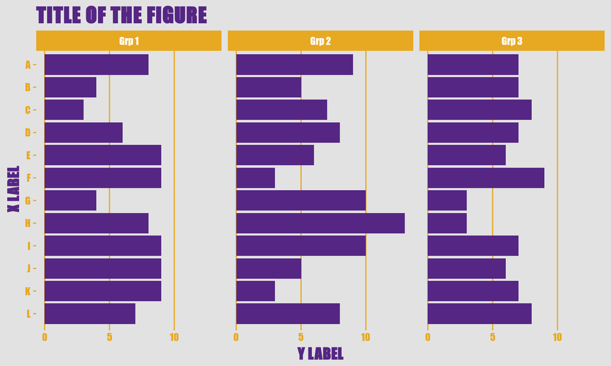

## Steep learning curve

- intimidating for beginners
- challenging for intermediate users
- however with proper approach it can be quite fun
- forget that R is a programming language
- and think about it as a statistical package (like SPSS)

## Some basic advices

- know where to find the newest version R cran.r-project.org
- use RStudio www.rstudio.com - the more advanced you become the more useful it will be
- know how to find help www.statmethods.net - read the docs!
- keep yourself engaged and be a part of the community: www.r-bloggers.com

## How not to loose your mind

- **always** save your code
- keep your code clear and organized: use comments, indentation, and spacing
- at least skim through Help pages before running a new function (e.g. ?lm)
- try do some working examples and understand how they work
- **do not** save your global environment when exiting R
- setting your working directory (setwd) might be a good idea (instead of working in a root directory)

## Errors happen

- don't panic - know how to distinguish messages, warnings, and errors
- carefully read the error message
- check your syntax, usually it is just a misspelled name, remember that R is case-sensitive (Rstudio **is not** RStudio)*
- read the docs - check the Usage and Arguments sections
- try to localize the place that causes the error and see what you can do
- *google* the error message